# Exercise 2

Pol Puig

July 15, 2020

Using the data file PAISOS.SAV assess variation on country life expectancy.

First of all, we are going to read the data using the following code:

```r
library(foreign)

paisos <- read.spss("http://84.89.132.1/~satorra/dades/PAISOS.SAV", use.value.labels = TRUE, to.data.frame =TRUE, use.missings = TRUE)
```

We also want to delete the countries with missing values:

```r
spaisos <- na.omit(subset(paisos,select=c(1,2,3,4,5,6,7,8,9)))
head(spaisos)
```

|  | IDH | NIVELL | PAIS | ESPVIDA | PIB | ALFAB | CONT | CALORIES | HABMETG |
| --- | --- | --- | --- | --- | --- | --- | --- | --- | --- |
| 1 | 167 | baix | Mozambique | 46.4 | 70 | 36.9 | Àfrica | 1680 | 33333 |
| 2 | 147 | baix | Tanzania | 52.1 | 100 | 64.4 | Àfrica | 2021 | 24970 |
| 3 | 171 | baix | Etiopia | 47.5 | 110 | 32.7 | Àfrica | 1610 | 33333 |
| 4 | 173 | baix | Sierra Leona | 39.0 | 160 | 28.7 | Àfrica | 1695 | 13620 |
| 6 | 151 | baix | Nepal | 53.5 | 170 | 25.6 | Àfrica | 1957 | 16667 |
| 7 | 158 | baix | Uganda | 44.9 | 180 | 58.6 | Àfrica | 2162 | 25000 |

### 1.- Univariate description of different variables:

#### Life Expectancy

```r
summary(spaisos$ESPVIDA)
```

```
##    Min. 1st Qu.  Median    Mean 3rd Qu.    Max.
##   39.00   55.73   67.55   64.50   73.47   79.50
```

As we can see, we get a large gap between the lowest and the maximum value of life expectancy. The median and mean although are not the same, are quite similar. Let’s get the countries that are on the extremes:

```r
spaisos$PAIS[spaisos$ESPVIDA == min(spaisos$ESPVIDA)]
```

```
## [1] "Sierra Leona    "
```

```r
spaisos$PAIS[spaisos$ESPVIDA == max(spaisos$ESPVIDA)]
```

```
## [1] "Japo            "
```

As we can see, the countries that are on the extremes on our dataset are Sierra Leona and Japan

#### Calories

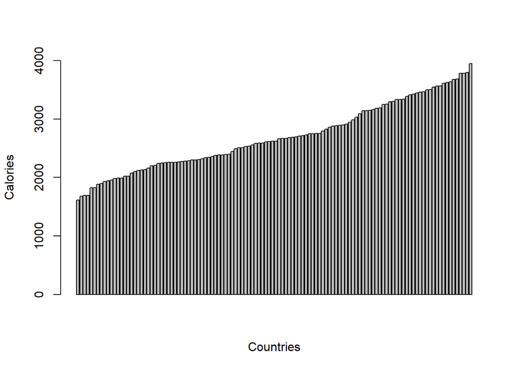

```r
barplot(sort(spaisos$CALORIES), xlab="Countries", ylab="Calories", ylim=c(0,4000))
```

```r
summary(spaisos$CALORIES)
```

```
##    Min. 1st Qu.  Median    Mean 3rd Qu.    Max.
##    1610    2260    2623    2693    3160    3947
```

We see that there is a large difference between the maximum and the minimum. Let’s check what country is the closest to the average (mean) of the sample:

```r
spaisos$PAIS[spaisos$CALORIES == (min(abs(spaisos$CALORIES - mean(spaisos$CALORIES)))+ mean(spaisos$CALORIES))]
```

```
## [1] "Mauricio        "
```

Mauricio islands is the country that its Calories are closer to the mean of the sample.

#### Development level

```r
table(spaisos$NIVELL)
```

```
##
##  baix mitjà   alt
##    34    37    47
```

### 2.- Plot ESPVIDA with colors varying with NIVELL. Brief description of the graph.

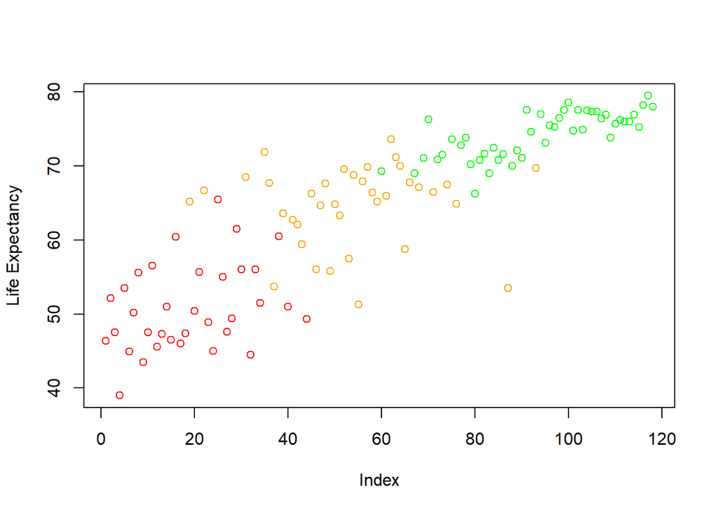

```r
spaisos$color = "black"
spaisos$color[spaisos$NIVELL == "alt"] = "green"
spaisos$color[spaisos$NIVELL == "mitjà"] = "orange"
spaisos$color[spaisos$NIVELL == "baix"] = "red"

plot(spaisos$ESPVIDA, col=spaisos$color,  ylab="Life Expectancy")
```

As we can see, the countries with lower HDI also have a lower life expectancy. In the graph, we colored the points in red for the low HDI countries, orange for the medium and green for the high ones.

### 3.- Scatterplot of ESPVIDA vs CALORIES

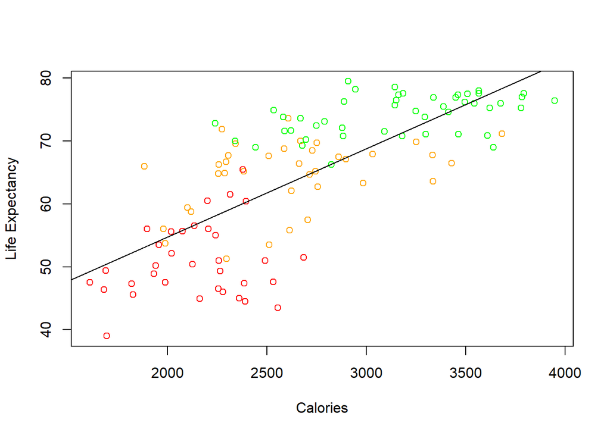

```r
plot(spaisos$CALORIES,spaisos$ESPVIDA, col=spaisos$color, xlab="Calories", ylab="Life Expectancy")
model1 <- lm(ESPVIDA ~ CALORIES, data=spaisos)
abline(model1)
```

As we can see, in average, the higher the calories value is, the higher is the life expectancy of the country. Although we can say this statement, there’s quite a large dispersion on our model. The result doesn’t impress me. I think that is quite obvious that these variables are correlated.

### 4.- Propose other plots/analysis that could explain the variability of ESPVIDA.

We are going to make a model consisting on relating the life expectancy and literacy index:

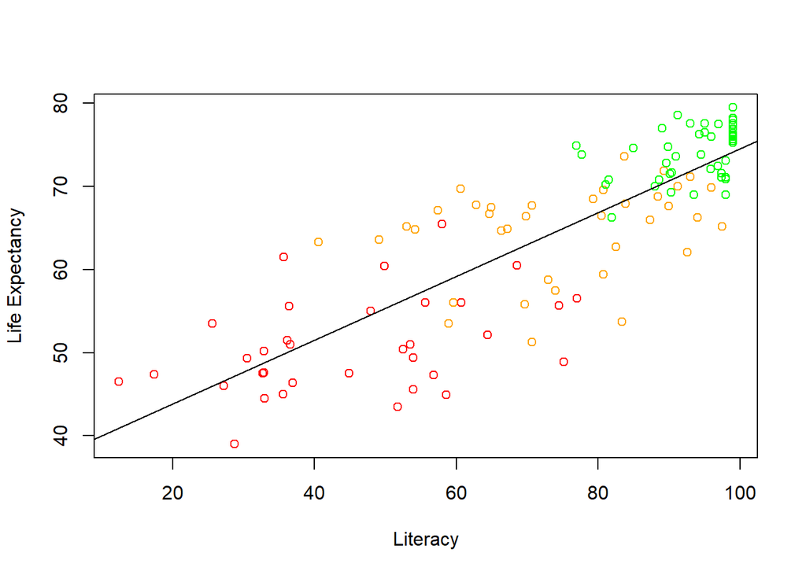

```r
plot(spaisos$ALFAB,spaisos$ESPVIDA, col=spaisos$color, xlab="Literacy", ylab="Life Expectancy")
model1 <- lm(ESPVIDA ~ ALFAB, data=spaisos)
abline(model1)
```

Looking the graph, we can conclude that there is also a correlation between the life expectancy and the literacy level of a country. We also have colored the countries based on the HDI. In this case, there is some overlapping between high and medium and medium and low HDI and the life expectancy~Literacy correlation.

Now we are going to run a regression between life expectancy and the number of citizens per doctor index:

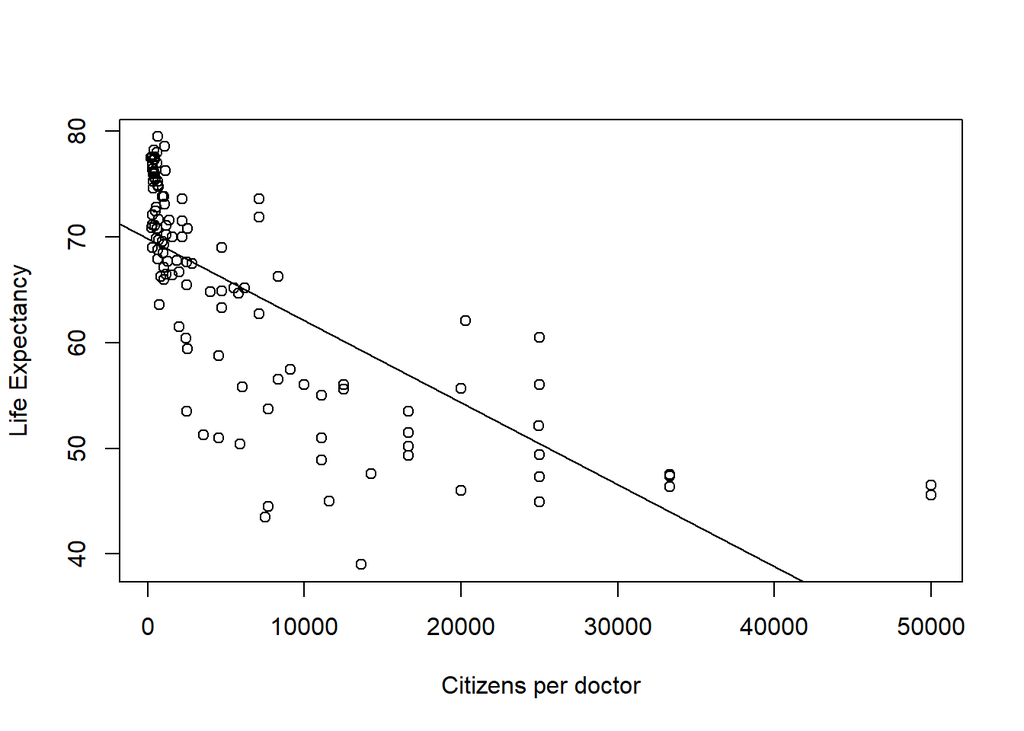

```r
plot(spaisos$HABMETG,spaisos$ESPVIDA, col="black", xlab="Citizens per doctor", ylab="Life Expectancy")
model1 <- lm(ESPVIDA ~ HABMETG, data=spaisos)
abline(model1)
```

As we can see, there is a lot of dispersion but in general terms, we can say that the less citizens per doctor there are in a country, the higher the life expectancy is.

### 5.- Brief repot to a non-expert in statistics of the analyses so far.

During the practice we have found that life expectancy of a country depends on different factors. First of all, we have seen that the higher the HDI level of a country is, the higher the life expectancy is. Another fact we have observed is that the higher the calories index is, the higher the life expectancy of a country will be. Then we discovered that literacy level of a country and its life expectancy are also related. A country with low life expectancy also generally have a low literacy level. In the end of our project, we made a relation between the life expectancy and the citizens per doctor index of each country. We found a negative relation: the more citizens per doctor are in a country, the lower is the life expectancy.